# Event Impact Analysis

Effect of public holidays, events and event size on `arrival_delay`.

## Setup

```python
from zh_tram_flow.notebook import *
from zh_tram_flow.cleaning import apply_lf_clean
import zh_tram_flow.analytics.events as an

TRAIN, TEST, lf, lf_all, lf_delay, lf_clean = setup_analysis("03_analysis_6-events")

lf_all = lf_all.with_columns(
    (pl.col("event_name").cast(pl.Utf8) != "no_event").alias("has_event")
)

lf_delay = lf_all.filter(pl.col("canceled") == False)
lf_clean = apply_lf_clean(lf_all)

%load_ext autoreload
%autoreload 2
```

```
✓  wgnd theme activated (matplotlib · seaborn)
```

```
2026-06-11 15:31:43  INFO      project  03_analysis_6-events started
```

```
The autoreload extension is already loaded. To reload it, use:
  %reload_ext autoreload
```

## Holidays

Public holidays vs normal days — does reduced traffic improve or worsen punctuality?

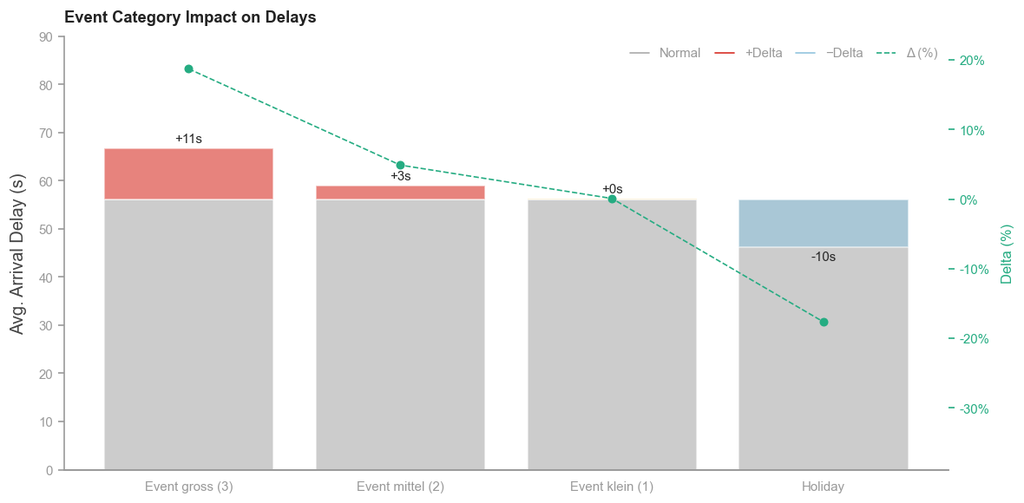

| Kategorie | Avg. Delay (s) | OTP | N Halte |
| --- | --- | --- | --- |
| Normal | 56.19 | 87.0% | 70,467,765 |
| Holiday | 46.28 | 90.6% | 2,323,806 |
| Event klein (1) | 56.24 | 86.9% | 8,723,187 |
| Event mittel (2) | 58.93 | 86.4% | 7,475,758 |
| Event gross (3) | 66.70 | 82.4% | 724,385 |

```python
an.plot_events_overview(lf_delay, cfg)

show_df(an.table_events_overview(lf_delay))
```

**Beobachtung:** Klares Ergebnis — aber mit einer Überraschung.

**Ø Delay nach Tages-Kategorie:**

| Kategorie | Ø Delay (s) | OTP | N |
| --- | --- | --- | --- |
| **Feiertag** | **46.3** | **90.6%** | 2.3M |
| Normal | 56.2 | 87.0% | 70.5M |
| Event klein (1) | **56.2** | 86.9% | 8.7M |
| Event mittel (2) | 58.9 | 86.4% | 7.5M |
| **Event gross (3)** | **66.7** | **82.4%** | 724k |

**Feiertagseffekt gegenläufig zur Erwartung:** Feiertage zeigen deutlich *weniger* Verspätung als Normaltage (46.3s vs. 56.2s, −9.9s, OTP +3.6pp). Weniger Berufsverkehr überwiegt den Freizeitverkehr an Feiertagen.

**Event-Skalierung bestätigt:** Gross-Events (+10.5s über Normal) haben klare Auswirkungen. Mittel-Events (+2.7s) sind messbar aber moderat. **Kleine Events (+0.05s) sind praktisch nicht von Normal zu unterscheiden** — Event-Gewicht 1 hat kaum Vorhersagekraft.

→ `is_holiday` als starkes Feature (−9.9s Effekt). `event_weight` als ordinales Feature; Klasse 1 eventuell binarisieren. Events sind selten (n=724k Gross, n=16.9M aller Events vs. 70.5M Normal) — Unbalanced-Class-Problem beachten.

## Daily Delay Timeline

Daily average delay per year — school holidays shaded, events marked by type. Shows whether delay spikes coincide with events.

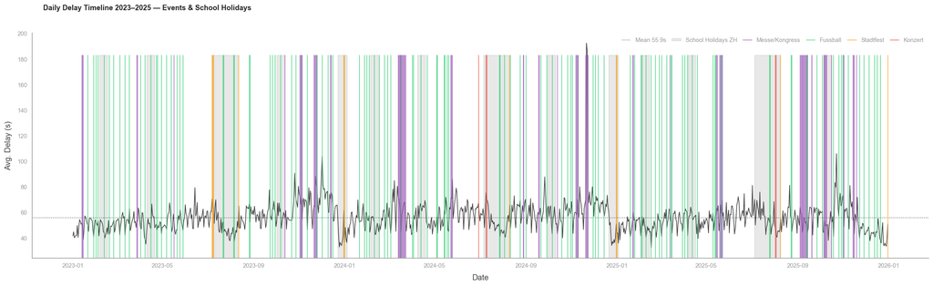

|  | Datum | Event-Typ | Event | Avg. Delay (s) | OTP | N Halte |
| --- | --- | --- | --- | --- | --- | --- |
| 0 | 2024-11-21 00:00:00 | Fachmesse | Berufsmesse Zürich | 192.50 | 67.8% | 77023 |
| 1 | 2024-11-22 00:00:00 | Fachmesse | Berufsmesse Zürich | 186.40 | 54.5% | 78971 |
| 2 | 2023-12-02 00:00:00 | Super League | GCZ vs FC Lausanne-Sport | 103.80 | 70.1% | 72871 |
| 3 | 2023-11-23 00:00:00 | Fachmesse | Berufsmesse Zürich | 88.30 | 76.5% | 82833 |
| 4 | 2024-05-25 00:00:00 | Fachmesse | Bildungsmesse Zürich HB | 85.90 | 79.2% | 73768 |
| 5 | 2023-11-24 00:00:00 | Fachmesse | Berufsmesse Zürich | 82.10 | 77.5% | 84103 |
| 6 | 2023-11-25 00:00:00 | Super League | FCZ vs BSC Young Boys | 80.50 | 78.5% | 71632 |
| 7 | 2023-11-25 00:00:00 | Fachmesse | Berufsmesse Zürich | 80.50 | 78.5% | 71632 |
| 8 | 2023-12-14 00:00:00 | Kongress | NOAH Zurich Conference | 75.50 | 79.2% | 82785 |
| 9 | 2024-07-09 00:00:00 | Konzert | Taylor Swift | 75.40 | 79.0% | 86172 |
| 10 | 2024-11-23 00:00:00 | Fachmesse | Berufsmesse Zürich | 75.40 | 79.5% | 78393 |
| 11 | 2024-11-23 00:00:00 | Super League | GCZ vs FC Winterthur | 75.40 | 79.5% | 78393 |
| 12 | 2025-11-01 00:00:00 | Fachmesse | FINEST AUDIO SHOW Zurich | 73.80 | 80.1% | 82059 |
| 13 | 2025-11-01 00:00:00 | Super League | FCZ vs FC Lausanne-Sport | 73.80 | 80.1% | 82059 |
| 14 | 2024-03-13 00:00:00 | Fachmesse | Giardina | 72.90 | 82.0% | 81232 |
| 15 | 2023-11-02 00:00:00 | Fachmesse | Master-Messe Zürich | 72.50 | 80.9% | 87961 |
| 16 | 2023-11-02 00:00:00 | Fachmesse | Auto Zürich | 72.50 | 80.9% | 87961 |
| 17 | 2024-05-23 00:00:00 | Fachmesse | Bildungsmesse Zürich HB | 71.50 | 79.0% | 81039 |
| 18 | 2023-11-04 00:00:00 | Super League | FCZ vs Servette FC | 71.10 | 81.3% | 71152 |
| 19 | 2023-11-04 00:00:00 | Fachmesse | Auto Zürich | 71.10 | 81.3% | 71152 |
| 20 | 2024-05-24 00:00:00 | Fachmesse | Bildungsmesse Zürich HB | 70.80 | 82.1% | 84411 |
| 21 | 2023-07-07 00:00:00 | Stadtfest | Züri Fäscht | 70.60 | 80.1% | 93642 |
| 22 | 2024-03-14 00:00:00 | Fachmesse | Giardina | 70.60 | 83.9% | 84868 |
| 23 | 2023-12-13 00:00:00 | Kongress | NOAH Zurich Conference | 70.60 | 81.3% | 83058 |
| 24 | 2024-07-10 00:00:00 | Konzert | Taylor Swift | 70.50 | 81.9% | 88026 |
| 25 | 2024-11-30 00:00:00 | Super League | FCZ vs Grasshopper Club Zürich | 70.50 | 81.4% | 76524 |
| 26 | 2024-11-20 00:00:00 | Fachmesse | Berufsmesse Zürich | 70.40 | 82.3% | 87648 |
| 27 | 2024-11-09 00:00:00 | Fachmesse | Auto Zürich | 69.90 | 81.6% | 79538 |
| 28 | 2023-10-28 00:00:00 | Super League | FCZ vs FC Stade-Lausanne-Ouchy | 69.70 | 81.8% | 70995 |
| 29 | 2025-05-22 00:00:00 | Super League | GCZ vs FC St. Gallen 1879 | 69.40 | 78.2% | 84127 |

```python
an.plot_daily_delay_timeline(lf_delay, cfg)

show_df(an.table_daily_delay_timeline(lf_delay))
```

**Beobachtung:** Der Plot und das Ranking liefern den entscheidenden Beweis — und korrigieren eine verbreitete Vermutung.

**Top Event-Tage nach Ø Arrival Delay:**

[output not shown]

**Kernbefund — der November-Peak ist kein Wetterproblem, es sind Fachmessen:** 17 von 30 schlechtesten Event-Tagen sind Fachmessen. Der November-Peak (F-TEMP-01 aus dem Temporal-Notebook) war bislang unerklärlich — die Antwort ist die **Berufsmesse Zürich**, die jedes Jahr Ende November das Netz lahmlegt.

**Überraschende Hierarchie:**

- Selbst **Taylor Swift** (75.4s) schlägt eine normale Berufsmesse nicht
- **Stadtfeste** (Züri Fäscht 70.6s) wirken dramatisch, liegen aber im Mittelfeld
- **Fachmessen** sind das eigentliche Systemproblem — nicht wegen Massen, sondern wegen Dauer: mehrere Tage, ganztags, immer auf dem gleichen L11-Korridor

→ **Präsentation:** Hot Insight — "Wir dachten es ist das Wetter im November. Es sind die Fachmessen."

## Event-Typ + Stunden-Profil

Welche Veranstaltungstypen haben den grössten Einfluss? Und: Wann schlägt der Effekt durch — zu welcher Stunde sind Event-Tage deutlich schlechter als Normaltage?

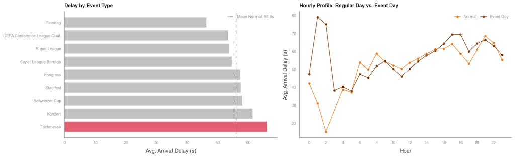

| hour | Normal (s) | N Normal | Event-Tag (s) | N Event | Δ (s) |
| --- | --- | --- | --- | --- | --- |
| 0 | 42.20 | 1815725 | 47.20 | 564695 | 5.00 |
| 1 | 31.10 | 82477 | 78.90 | 48279 | 47.80 |
| 2 | 15.10 | 495 | 75.00 | 11053 | 59.90 |
| 4 | 38.70 | 94234 | 40.10 | 30178 | 1.40 |
| 5 | 37.20 | 2077410 | 37.90 | 576445 | 0.70 |
| 6 | 53.80 | 3658881 | 47.20 | 840637 | -6.70 |
| 7 | 49.70 | 3871569 | 45.30 | 903795 | -4.50 |
| 8 | 58.70 | 3911370 | 51.70 | 945999 | -7.00 |
| 9 | 54.30 | 3820001 | 54.60 | 974901 | 0.40 |
| 10 | 52.20 | 3948231 | 50.10 | 1108684 | -2.10 |
| 11 | 50.10 | 3984166 | 45.90 | 1120087 | -4.20 |
| 12 | 53.70 | 3991828 | 50.00 | 1116059 | -3.70 |
| 13 | 56.00 | 3974605 | 54.40 | 1113715 | -1.60 |
| 14 | 58.60 | 3957071 | 57.70 | 1112078 | -0.90 |
| 15 | 61.20 | 4000483 | 60.30 | 1103486 | -0.90 |
| 16 | 61.40 | 4071069 | 64.20 | 1105988 | 2.80 |
| 17 | 64.10 | 4084912 | 69.30 | 1105376 | 5.20 |
| 18 | 58.70 | 4020597 | 69.30 | 1095672 | 10.60 |
| 19 | 53.00 | 3940701 | 59.90 | 1082307 | 6.90 |
| 20 | 61.00 | 3582251 | 64.30 | 997046 | 3.30 |
| 21 | 68.40 | 2691105 | 66.30 | 805616 | -2.10 |
| 22 | 64.60 | 2622296 | 63.00 | 786129 | -1.60 |
| 23 | 55.40 | 2266288 | 58.00 | 698433 | 2.60 |

```python
an.plot_event_type_hourly_profile(lf_delay, cfg)
show_df(an.table_event_type_hourly_profile(lf_delay))
```

**Beobachtung — Nachteffekt & Morgenparadox:**

**1–2h: Der Heimkehrer-Spike.** Auf Normaltagen fahren um 2h nur 495 Halte (quasi keine Trams). Auf Event-Tagen sind es 11.053 — die Heimkehrer nach Konzerten und Stadtfesten füllen die letzten Kurse. Delay springt von 15s auf 75s (Δ +59.9s). Das ist kein Messrauschen, sondern ein reales Phänomen: Events verlängern den Betrieb in die Nacht.

**6–12h: Event-Tage besser als Normal (negatives Δ).** Event-Tage enthalten auch Feiertage — der reduzierte Berufsverkehr am Morgen zieht den Durchschnitt nach unten. Der positive Event-Effekt aus F-EVNT-01 (Feiertage −9.9s) schlägt hier durch.

**18h: Die Abreisewelle.** +10.6s um 18h bestätigt F-EVNT-03 — der Abend-Peak wenn Veranstaltungen enden.

**Event-Typ-Ranking:**

| Event-Typ | Ø Delay (s) | OTP | N |
| --- | --- | --- | --- |
| **Fachmesse** | **66.0** | 84% | 4.3M |
| Konzert | 61.4 | 85% | 403k |
| Schweizer Cup | 58.1 | 87% | 348k |
| Stadtfest | 57.6 | 86% | 859k |
| Kongress | 57.4 | 86% | 2.5M |
| Super League | 53.8 | 88% | 8.2M |
| Feiertag | 46.3 | 91% | 2.3M |

**Kernbefund:** **Fachmessen** (66.0s, OTP 84%) sind die problematischste Veranstaltungskategorie — nicht Konzerte wie ursprünglich angenommen. Fachmessen dauern ganztags über mehrere Tage (Messe Zürich / L11-Korridor). Konzerte (61.4s) sind punktueller aber intensiver (kurze Abreisewelle nach Konzertende).

**Super League** (53.8s, 8.2M Halte) — viele Beobachtungen aber nahe Normal — Fussballspiele verteilen sich besser über den Tag (lange Anfahrt, Fankurven früh präsent).

→ `event_type` als kategorisches Feature; `is_holiday` als stärkstes negatives Signal (46.3s); Fachmessen-Effekt besonders für L11-Prognose relevant.

## Event-Standorte — Stadtkreise

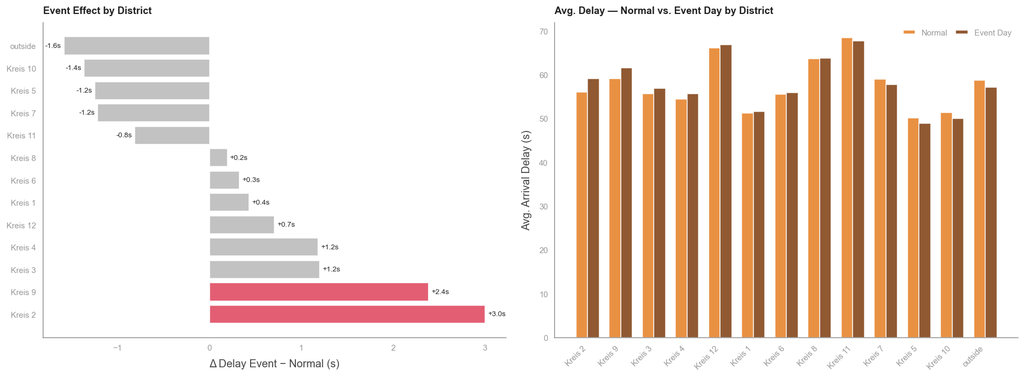

| District | Normal (s) | Event-Tag (s) | Δ (s) | N Halte (Events) |
| --- | --- | --- | --- | --- |
| Kreis 2 | 56.10 | 59.10 | 3.00 | 1,218,286 |
| Kreis 9 | 59.10 | 61.50 | 2.40 | 917,796 |
| Kreis 3 | 55.70 | 56.90 | 1.20 | 1,044,697 |
| Kreis 4 | 54.50 | 55.70 | 1.20 | 1,623,785 |
| Kreis 12 | 66.10 | 66.80 | 0.70 | 900,360 |
| Kreis 1 | 51.20 | 51.70 | 0.40 | 3,880,130 |
| Kreis 6 | 55.60 | 55.90 | 0.30 | 2,719,031 |
| Kreis 8 | 63.60 | 63.80 | 0.20 | 779,710 |
| Kreis 11 | 68.50 | 67.70 | -0.80 | 1,213,499 |
| Kreis 7 | 59.00 | 57.80 | -1.20 | 1,252,520 |
| Kreis 5 | 50.20 | 48.90 | -1.20 | 1,889,417 |
| Kreis 10 | 51.30 | 50.00 | -1.40 | 559,348 |
| outside | 58.80 | 57.20 | -1.60 | 1,248,557 |

|  | Stop | District | Normal (s) | Event-Tag (s) | Δ (s) | N Halte (Events) |
| --- | --- | --- | --- | --- | --- | --- |
| 0 | Zürich, Bachmattstrasse | Kreis 9 | 61.60 | 69.70 | 8.10 | 60513 |
| 1 | Zürich, Grimselstrasse | Kreis 9 | 59.70 | 67.00 | 7.30 | 60208 |
| 2 | Zürich, Farbhof | Kreis 9 | 62.40 | 68.70 | 6.30 | 61365 |
| 3 | Zürich, Lindenplatz | Kreis 9 | 63.80 | 69.70 | 5.90 | 61312 |
| 4 | Zürich, Museum Rietberg | Kreis 2 | 54.30 | 59.80 | 5.50 | 66535 |
| 5 | Zürich, Micafil | Kreis 9 | 65.50 | 70.90 | 5.30 | 61322 |
| 6 | Zürich, Siemens | Kreis 9 | 60.40 | 65.40 | 5.00 | 61233 |
| 7 | Schlieren, Mülligen | outside | 53.70 | 58.30 | 4.60 | 61400 |
| 8 | Zürich, Brunaustrasse | Kreis 2 | 57.50 | 62.20 | 4.60 | 67421 |
| 9 | Schlieren, Zentrum/Bahnhof | outside | 48.70 | 53.10 | 4.30 | 61397 |
| 10 | Zürich, Fröhlichstrasse | Kreis 8 | 67.70 | 72.00 | 4.30 | 118469 |
| 11 | Zürich, Heerenwiesen | Kreis 12 | 68.50 | 72.80 | 4.30 | 60034 |
| 12 | Zürich, Friedhof Enzenbühl | Kreis 8 | 92.90 | 97.10 | 4.20 | 63714 |
| 13 | Zürich, Freihofstrasse | Kreis 9 | 54.50 | 58.60 | 4.10 | 63600 |
| 14 | Zürich, Bahnhof Enge | Kreis 2 | 52.70 | 56.70 | 4.10 | 99671 |
| 15 | Zürich, Laubegg | Kreis 3 | 53.00 | 57.00 | 4.10 | 66602 |
| 16 | Zürich, Kappeli | Kreis 9 | 56.30 | 60.40 | 4.10 | 60107 |
| 17 | Schlieren, Gasometerbrücke | outside | 56.70 | 60.80 | 4.00 | 61428 |
| 18 | Zürich, Zypressenstrasse | Kreis 4 | 52.00 | 56.00 | 4.00 | 99131 |
| 19 | Zürich, Letzigrund | Kreis 4 | 55.40 | 59.40 | 3.90 | 62959 |

```python
an.plot_event_district_effect(lf_delay, cfg)
show_df(an.table_event_district_effect(lf_delay))

an.plot_event_stop_map(lf_delay)
show_df(an.table_event_stop_map(lf_delay))
```

[output not shown]

**Beobachtung — Räumliche Event-Muster:**

**Kreis 9 — Ausstrahlungskorridor:** Die erhöhten Werte entlang Linie 2 (Bachmattstrasse, Grimselstrasse, Farbhof, Lindenplatz) zeigen dass Event-Delays von der Innenstadt nach Westen propagieren. K9 ist der Heimweg für Besucher aus dem Umland — Messe Zürich und Hallenstadion entlassen ihr Publikum direkt in diesen Korridor.

**Kreis 2 — Bahnhof- und Stadion-Zugang:** Bahnhof Enge und Museum Rietberg (Linie 7/13) sind Umsteigeknoten für Event-Besucher. K2 verbindet Innenstadt mit dem Süden der Stadt und dem Bahnhof Enge als Endpunkt mehrerer Linien.

**Kreis 4 — Stadion-Korridor:** Zypressenstrasse und Letzigrund (FCZ-Stadion) zeigen dass K4 bei Fussball-Events unter Druck steht. Der Korridor ist stark befahren und hat wenig Puffer bei zusätzlichem Ansturm.

**Kreis 3 — Innenstadt-Effekt:** Analog zu K4, aber als direkter Innenstadteffekt. K3 (Wiedikon/Sihlfeld) liegt auf den gleichen Durchgangskorridoren und trägt den erhöhten Druck wenn die Innenstadt bei Events überlastet ist.

**Beobachtung:** Der Event-Effekt auf Stadtkreis-Ebene ist überraschend klein — und in mehreren Kreisen sogar negativ.

**Δ Delay Event-Tag vs. Normaltag nach Stadtkreis:**

| Stadtkreis | Normal (s) | Event-Tag (s) | Δ |
| --- | --- | --- | --- |
| Kreis 2 | 56.1 | 59.1 | **+3.0** |
| Kreis 9 | 59.1 | 61.5 | **+2.4** |
| Kreis 3 | 55.7 | 56.9 | +1.2 |
| Kreis 4 | 54.5 | 55.7 | +1.2 |
| Kreis 11 | 68.5 | 67.7 | **−0.8** (leicht besser!) |
| Kreis 5 | 50.2 | 48.9 | −1.2 |
| outside | 58.8 | 57.2 | −1.6 |

**Kernbefund:** Nur Kreise 2 (+3.0s) und 9 (+2.4s) zeigen messbare positive Event-Effekte. Kreis 11 (wo Hallenstadion und Messe Zürich liegen!) zeigt an Event-Tagen sogar leicht *niedrigere* Delays (−0.8s) — überraschend.

**Erklärungsansatz:** Die Event-Klassifizierung ist netzweit (ganzer Betriebstag), nicht linienbezogen. Der starke Effekt einer Fachmesse auf L11-Abendstunden wird durch den gesamten Tagesbetrieb von Kreis 11 "verdünnt". Ein Kreis-Δ von +3.0s entspricht einem sehr kleinen Effekt relativ zur Kreis-Streuung — die räumliche Aggregation verbirgt den zeitlichen (Abend-)Effekt.

→ Feature-Empfehlung: `has_event × hour` Interaktion ist aussagekräftiger als nur `district × has_event`. Der Abend-Effekt (F-EVNT-03) bleibt die stärkste räumlich-zeitliche Signatur.

## Kapazitäts-Erholung: Feiertag vs. Wochenende vs. Normaltag

Wenn Pendler ausbleiben und der Privatverkehr zurückgeht, erholt sich das Tramnetz — ohne jede Taktänderung.

Feiertage erreichen nahezu Wochenend-Niveau oder unterschreiten es. Kernbotschaft: **Die Kapazitätsgrenze des Netzes liegt beim Strassenverkehr**, nicht beim Fahrgastaufkommen. Das Netz könnte strukturell besser performen — wenn der MIV reduziert wird.

Drei Kurven: `Normaler Werktag` · `Wochenende` · `Feiertag` — pro Stunde (0–23 h).

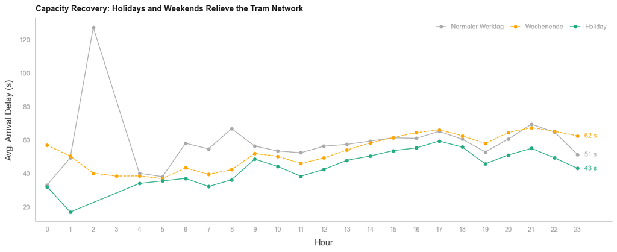

```python
an.plot_holiday_recovery(lf_delay)
```

## Haltestellen- & Linien-Ranking

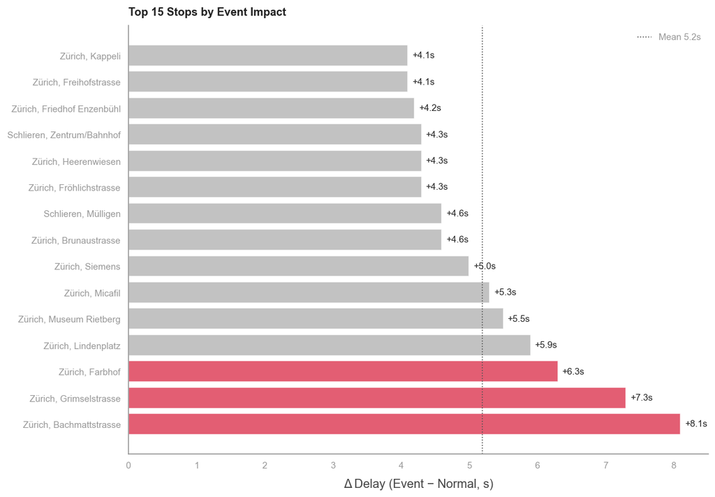

|  | Stop | District | Normal (s) | Event-Tag (s) | Δ (s) | N Halte (Events) |
| --- | --- | --- | --- | --- | --- | --- |
| 0 | Zürich, Bachmattstrasse | Kreis 9 | 61.60 | 69.70 | 8.10 | 60513 |
| 1 | Zürich, Grimselstrasse | Kreis 9 | 59.70 | 67.00 | 7.30 | 60208 |
| 2 | Zürich, Farbhof | Kreis 9 | 62.40 | 68.70 | 6.30 | 61365 |
| 3 | Zürich, Lindenplatz | Kreis 9 | 63.80 | 69.70 | 5.90 | 61312 |
| 4 | Zürich, Museum Rietberg | Kreis 2 | 54.30 | 59.80 | 5.50 | 66535 |
| 5 | Zürich, Micafil | Kreis 9 | 65.50 | 70.90 | 5.30 | 61322 |
| 6 | Zürich, Siemens | Kreis 9 | 60.40 | 65.40 | 5.00 | 61233 |
| 7 | Schlieren, Mülligen | outside | 53.70 | 58.30 | 4.60 | 61400 |
| 8 | Zürich, Brunaustrasse | Kreis 2 | 57.50 | 62.20 | 4.60 | 67421 |
| 9 | Zürich, Fröhlichstrasse | Kreis 8 | 67.70 | 72.00 | 4.30 | 118469 |
| 10 | Schlieren, Zentrum/Bahnhof | outside | 48.70 | 53.10 | 4.30 | 61397 |
| 11 | Zürich, Heerenwiesen | Kreis 12 | 68.50 | 72.80 | 4.30 | 60034 |
| 12 | Zürich, Friedhof Enzenbühl | Kreis 8 | 92.90 | 97.10 | 4.20 | 63714 |
| 13 | Zürich, Bahnhof Enge | Kreis 2 | 52.70 | 56.70 | 4.10 | 99671 |
| 14 | Zürich, Laubegg | Kreis 3 | 53.00 | 57.00 | 4.10 | 66602 |
| 15 | Zürich, Kappeli | Kreis 9 | 56.30 | 60.40 | 4.10 | 60107 |
| 16 | Zürich, Freihofstrasse | Kreis 9 | 54.50 | 58.60 | 4.10 | 63600 |
| 17 | Schlieren, Gasometerbrücke | outside | 56.70 | 60.80 | 4.00 | 61428 |
| 18 | Zürich, Zypressenstrasse | Kreis 4 | 52.00 | 56.00 | 4.00 | 99131 |
| 19 | Zürich, Letzigrund | Kreis 4 | 55.40 | 59.40 | 3.90 | 62959 |

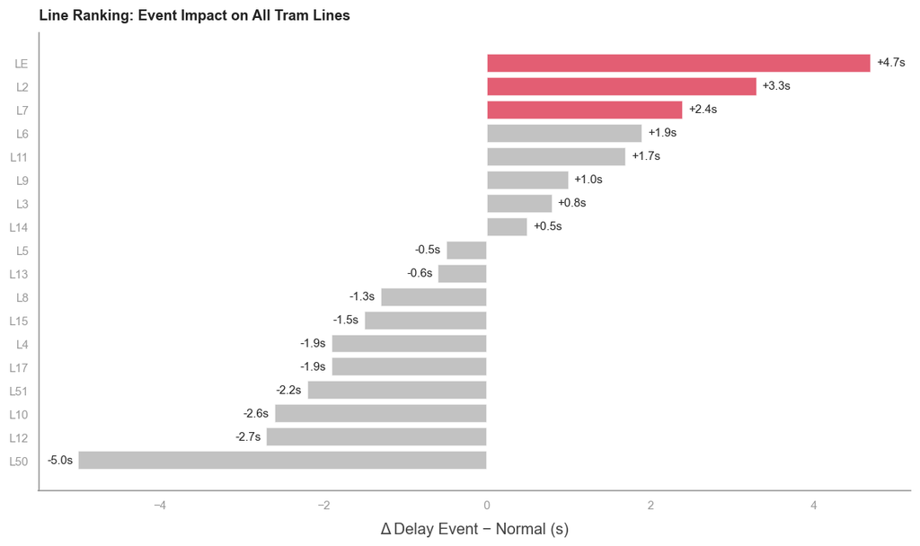

| Line | Normal (s) | Event-Tag (s) | Δ (s) | ΔOTP (pp) | N Halte (Events) |
| --- | --- | --- | --- | --- | --- |
| LE | 129.40 | 134.10 | 4.70 | 4.20 | 390 |
| L2 | 55.50 | 58.80 | 3.30 | -1.40 | 1,708,790 |
| L7 | 58.30 | 60.70 | 2.40 | -0.60 | 1,775,931 |
| L6 | 38.00 | 39.90 | 1.90 | -0.40 | 765,213 |
| L11 | 68.40 | 70.10 | 1.70 | -0.50 | 1,957,473 |
| L9 | 55.40 | 56.40 | 1.00 | 0.10 | 1,775,814 |
| L3 | 53.70 | 54.50 | 0.80 | -0.70 | 1,127,609 |
| L14 | 55.40 | 55.90 | 0.50 | -0.10 | 1,535,369 |
| L5 | 47.50 | 47.00 | -0.50 | 0.50 | 620,165 |
| L13 | 52.70 | 52.10 | -0.60 | 0.60 | 1,799,252 |
| L8 | 60.00 | 58.70 | -1.30 | 0.40 | 1,358,981 |
| L15 | 61.70 | 60.20 | -1.50 | 0.10 | 437,069 |
| L17 | 48.30 | 46.40 | -1.90 | 0.70 | 954,245 |
| L4 | 57.80 | 56.00 | -1.90 | 0.40 | 1,449,569 |
| L51 | 41.90 | 39.70 | -2.20 | 0.80 | 31,249 |
| L10 | 60.60 | 58.00 | -2.60 | 0.80 | 1,352,660 |
| L12 | 52.40 | 49.70 | -2.70 | 0.60 | 559,110 |
| L50 | 47.90 | 42.90 | -5.00 | 2.20 | 38,247 |

```python
an.plot_event_stop_ranking(lf_delay, cfg)

show_df(an.table_event_stop_map(lf_delay))

an.plot_event_line_ranking(lf_delay, cfg)

show_df(an.table_event_line_ranking(lf_delay))
```

## Key Findings

→ Vollständige Findings-Tabelle mit Impact und Action in `03_analysis_0-overview.ipynb`.

[output not shown]